# Módulo 3. Pseudolandmarks a lo largo del contorno

Curso corto: Análisis de contornos de otolitos con R

Luis Cubillos

Noviembre 2026

# Objetivos del módulo

1. Pasar del contorno de **píxeles** a un número fijo de **pseudolandmarks**.
2. Comparar el muestreo por **abscisa curvilínea** y por **radios equiangulares**.
3. Controlar el **punto de inicio** y el **sentido** de recorrido.
4. Calcular **descriptores de tamaño** e **índices de forma**.
5. Escribir una función que procese **una imagen** y luego **un lote** de imágenes.

# Punto de partida: el contorno del módulo 2

```r
G <- read.pnm("datos/otolito_scom.pgm")@grey
binarizar <- function(G, umbral) {
  B <- ifelse(G > umbral, 0, 1)
  B[c(1, nrow(B)), ] <- 1; B[, c(1, ncol(B))] <- 1
  B
}
B <- binarizar(G, 0.35)
pix <- which(B == 0, arr.ind = TRUE)
inicio <- c(round(median(pix[, "col"])), nrow(B) - round(median(pix[, "row"])))
cont <- Conte(inicio, B)          # o bien: cont <- readRDS("datos/contorno_pixeles.rds")
length(cont$X)                    # nº de píxeles del borde
```

```
#> [1] 1051
```

Más de mil puntos, separados por **1 píxel**, y distintos en número para cada otolito. Para comparar individuos se necesita **el mismo número de puntos** en posiciones **equivalentes**.

# Muestreo de pseudolandmarks

# Abscisa curvilínea (Claude 2008, p. 52)

Como `Conte()` entrega un punto por píxel, basta tomar índices regularmente espaciados con `seq()`:

```r
np  <- 50
idx <- round(seq(1, length(cont$X), length = np + 1))[-1]   # se descarta el último (= primero)
M   <- cbind(x = cont$X[idx], y = cont$Y[idx])
dim(M)
```

```
#> [1] 50  2
```

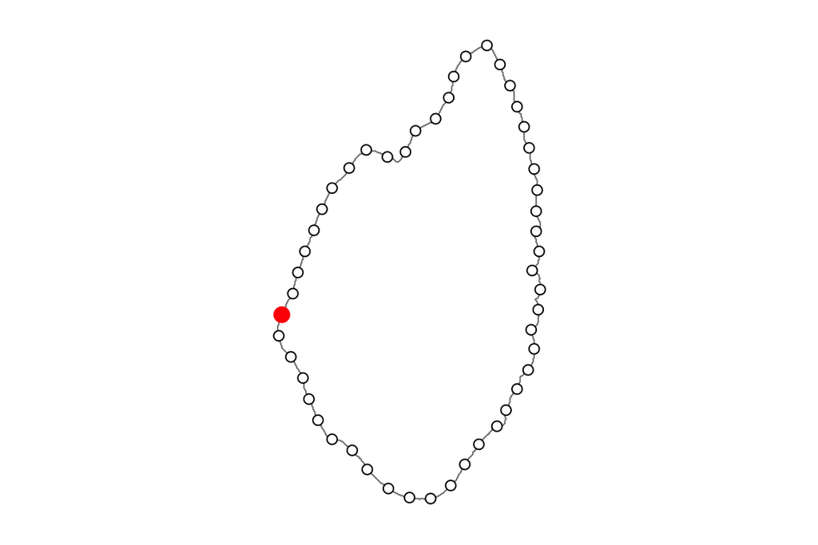

```r
par(mar = c(1, 1, 1, 1))
plot(cont$X, cont$Y, type = "l", asp = 1, axes = FALSE, xlab = "", ylab = "", col = "grey50")
points(M, pch = 21, bg = "white"); points(M[1, , drop = FALSE], pch = 19, col = "red", cex = 1.5)
```

# ¿Realmente equiespaciados?

En una grilla de píxeles un paso diagonal mide $\sqrt{2}$ y uno horizontal 1: el muestreo por **índice** no es exactamente equidistante. *Complemento*: interpolar a lo largo del **perímetro acumulado**.

```r
equiespaciar <- function(X, Y, n) {
  xy <- rbind(cbind(X, Y), c(X[1], Y[1]))               # contorno cerrado
  s  <- c(0, cumsum(sqrt(rowSums(diff(xy)^2))))         # distancia acumulada
  si <- seq(0, max(s), length = n + 1)[-(n + 1)]        # n distancias iguales
  cbind(x = approx(s, xy[, 1], si)$y, y = approx(s, xy[, 2], si)$y)
}
M2 <- equiespaciar(cont$X, cont$Y, np)
paso <- function(M) sqrt(rowSums(diff(rbind(M, M[1, ]))^2))
round(rbind(indice = summary(paso(M)), perimetro = summary(paso(M2))), 2)
```

```
#>            Min. 1st Qu. Median  Mean 3rd Qu.  Max.
#> indice    18.36   21.21  22.65 22.53   23.71 28.32
#> perimetro 16.22   22.48  22.99 22.46   23.22 24.01
```

Con el perímetro acumulado los tramos **a lo largo del borde** miden exactamente lo mismo; las cuerdas (rectas entre puntos) varían menos que con el muestreo por índice.

# Radios equiangulares (Claude 2008, función 2.6)

`regularradius()` elige los puntos del contorno a **ángulos iguales** desde el centroide. Es el muestreo del Fourier de radios (polar).

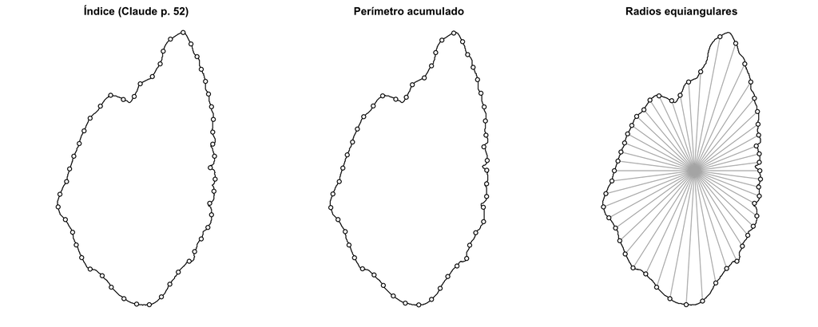

```r
rr <- regularradius(cont$X, cont$Y, np)
Xc <- mean(cont$X); Yc <- mean(cont$Y)
par(mfrow = c(1, 3), mar = c(1, 1, 2, 1))
plot(cont$X, cont$Y, type = "l", asp = 1, axes = FALSE, xlab = "", ylab = "", main = "Índice (Claude p. 52)")
points(M, pch = 21, bg = "white")
plot(cont$X, cont$Y, type = "l", asp = 1, axes = FALSE, xlab = "", ylab = "", main = "Perímetro acumulado")
points(M2, pch = 21, bg = "white")
plot(cont$X, cont$Y, type = "l", asp = 1, axes = FALSE, xlab = "", ylab = "", main = "Radios equiangulares")
segments(Xc, Yc, rr$coord[, 1] + Xc, rr$coord[, 2] + Yc, col = "grey70")
points(rr$coord[, 1] + Xc, rr$coord[, 2] + Yc, pch = 21, bg = "white")
```

# ¿Cuál usar?

| Muestreo | Uso | Ventaja | Problema |
| --- | --- | --- | --- |
| Abscisa curvilínea | Fourier **elíptico** | Puntos repartidos según la longitud del borde | Requiere punto de inicio homólogo |
| Radios equiangulares | Fourier de **radios** | Un solo valor (*r*) por ángulo | Pocos puntos en salientes alargadas (rostro); falla si un radio corta el contorno 2 veces |

En otolitos, con rostro y antirostro marcados, se recomienda la **abscisa curvilínea** + Fourier elíptico (Claude 2008, secc. 5.2.1 y 5.2.3).

# ¿Cuántos puntos?

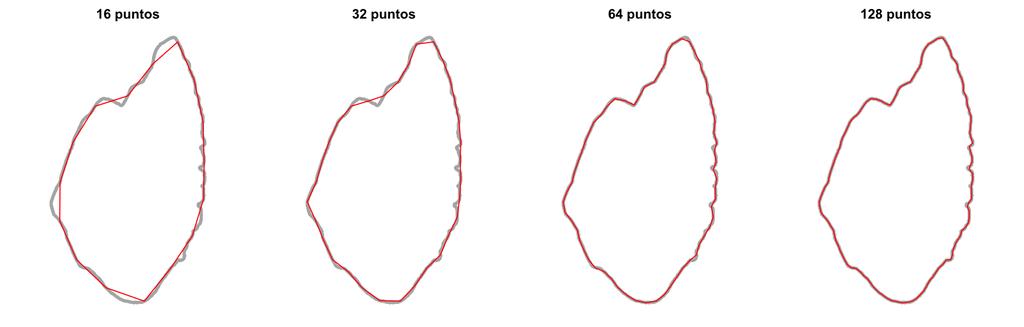

```r
par(mfrow = c(1, 4), mar = c(1, 1, 2, 1))
for (n in c(16, 32, 64, 128)) {
  Mn <- equiespaciar(cont$X, cont$Y, n)
  plot(cont$X, cont$Y, type = "l", asp = 1, axes = FALSE, xlab = "", ylab = "", col = "grey70", lwd = 3,
       main = paste(n, "puntos"))
  polygon(Mn, border = "red")
}
```

- Con *p* puntos se estiman como máximo **p / 2 armónicos** de Fourier.
- Deben bastar para seguir los detalles del borde (crenulaciones) sin sobremuestrear el ruido de los píxeles.
- Los datos del curso usan **50 puntos** por otolito (hasta 25 armónicos).

# Punto de inicio y sentido

# Correspondencia entre otolitos

El punto *i* de un otolito se compara con el punto *i* de los demás: todos deben **comenzar en la misma zona** del contorno y **recorrerse en el mismo sentido**.

```r
area_con_signo <- function(M) {             # fórmula del polígono (shoelace)
  x <- M[, 1]; y <- M[, 2]
  sum(x * c(y[-1], y[1]) - c(x[-1], x[1]) * y) / 2
}
area_con_signo(M2)      # > 0: antihorario; < 0: horario
```

```
#> [1] 75101.92
```

```r
antihorario <- function(M) if (area_con_signo(M) < 0) M[nrow(M):1, ] else M
iniciar_en  <- function(M, i) M[c(i:nrow(M), seq_len(i - 1)), ]   # rota el orden
# Criterio simple: comenzar en el punto más a la izquierda (otolitos orientados igual)
M2 <- antihorario(M2)
M2 <- iniciar_en(M2, which.min(M2[, 1]))
```

`Conte()` recorre el borde en sentido horario **en la matriz** (fila hacia abajo); al pasar a coordenadas del gráfico (*y* hacia arriba) el sentido se invierte. Los contornos de merluza del curso son **antihorarios** y comienzan en el punto más a la izquierda: se adopta esa misma convención.

# Efecto del punto de inicio

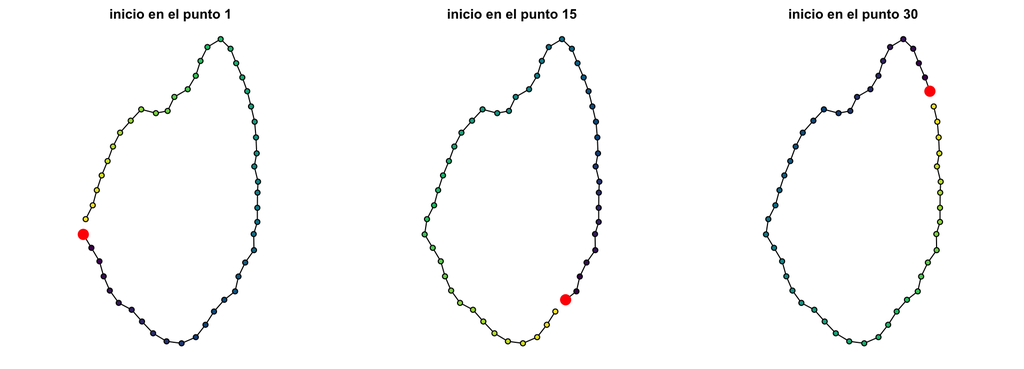

```r
par(mfrow = c(1, 3), mar = c(1, 1, 2, 1))
for (i in c(1, 15, 30)) {
  Mi <- iniciar_en(M2, i)
  plot(Mi, type = "l", asp = 1, axes = FALSE, xlab = "", ylab = "", main = paste("inicio en el punto", i))
  points(Mi, pch = 21, bg = hcl.colors(np, "viridis"))
  points(Mi[1, , drop = FALSE], pch = 19, col = "red", cex = 2)
}
```

Misma forma, **matrices distintas**. La normalización de Fourier (módulo 5) corrige parte del problema, pero conviene **digitalizar siempre desde la misma zona** y con la misma orientación (otolito izquierdo, cara interna, rostro a la izquierda).

# Descriptores de tamaño y forma

# Tamaño: área, perímetro, largo y ancho

```r
mm_por_pixel <- NA                 # p. ej. 1 / escala_px; NA = trabajar en píxeles
xy <- cbind(cont$X, cont$Y)
if (!is.na(mm_por_pixel)) xy <- xy * mm_por_pixel

perimetro <- sum(paso(xy))
area      <- abs(area_con_signo(xy))
# Largo = diámetro de Feret (máxima distancia); ancho = perpendicular al largo
d  <- as.matrix(dist(xy)); ij <- which(d == max(d), arr.ind = TRUE)[1, ]
v  <- xy[ij[2], ] - xy[ij[1], ]; a <- atan2(v[2], v[1])
xr <- xy %*% matrix(c(cos(a), -sin(a), sin(a), cos(a)), 2, 2)   # largo sobre el eje x
largo <- diff(range(xr[, 1])); ancho <- diff(range(xr[, 2]))
round(c(area = area, perimetro = perimetro, largo = largo, ancho = ancho), 1)
```

```
#>      area perimetro     largo     ancho
#>   75442.0    1243.0     438.2     277.9
```

El área por fórmula del polígono coincide con el conteo de píxeles del módulo 2 (`sum(B == 0)`) salvo por el borde.

# Índices de forma

```r
indices <- c(circularidad    = perimetro^2 / area,          # 4π ≈ 12.6 en un círculo
             redondez        = 4 * area / (pi * largo^2),   # 1 en un círculo
             rectangularidad = area / (largo * ancho),      # 1 en un rectángulo
             elipticidad     = (largo - ancho) / (largo + ancho),
             aspecto         = largo / ancho)
round(indices, 3)
```

```
#>    circularidad        redondez rectangularidad     elipticidad         aspecto
#>          20.481           0.500           0.619           0.224           1.577
```

Las definiciones de estos índices varían entre autores y programas (p. ej., ImageJ define circularidad como $4\pi A / P^2$). Indique siempre la fórmula usada. Son **adimensionales**, pero resumen la forma en un número: no permiten reconstruirla (para eso, Fourier).

# Del archivo de imagen a la matriz de 50 puntos

# Una función para una imagen

```r
contorno_desde_imagen <- function(archivo, umbral = 0.35, np = 50) {
  img <- read.pnm(archivo)
  if (is(img, "pixmapRGB")) img <- as(img, "pixmapGrey")
  B   <- binarizar(img@grey, umbral)
  pix <- which(B == 0, arr.ind = TRUE)
  ini <- c(round(median(pix[, "col"])), nrow(B) - round(median(pix[, "row"])))
  ct  <- Conte(ini, B)
  M   <- equiespaciar(ct$X, ct$Y, np)
  M   <- antihorario(M)
  iniciar_en(M, which.min(M[, 1]))
}
xy50 <- contorno_desde_imagen("datos/otolito_scom.pgm")
head(xy50, 4)
```

```
#>             x        y
#> [1,] 258.0000 248.9065
#> [2,] 269.9883 229.0117
#> [3,] 281.9104 209.0896
#> [4,] 288.1757 186.8243
```

# Un lote de imágenes

```r
# Una carpeta por zona: Fotos/Zona1/*.pgm, Fotos/Zona2/*.pgm, ...
archivos <- list.files("Fotos", pattern = "\\.(pgm|ppm)$", recursive = TRUE, full.names = TRUE)
lista <- lapply(archivos, contorno_desde_imagen)
names(lista) <- tools::file_path_sans_ext(basename(archivos))
saveRDS(lista, "datos/contornos_lote.rds")
```

**Control visual obligatorio**: reflejos, otolitos rotos o partículas pegadas al borde producen contornos erróneos que el análisis no detecta.

```r
pdf("control_contornos.pdf", width = 10, height = 8)
par(mfrow = c(4, 5), mar = c(0.5, 0.5, 2, 0.5))
for (n in names(lista)) {
  plot(lista[[n]], type = "l", asp = 1, axes = FALSE, main = n, cex.main = 0.8)
  points(lista[[n]][1, , drop = FALSE], pch = 19, col = "red")
}
dev.off()
```

# Resumen y ejercicio

contorno (píxeles) → `equiespaciar()` o `seq()` → 50 pseudolandmarks → sentido antihorario → inicio común → matriz 50 × 2

**Ejercicio**

1. Obtenga 32, 50 y 100 pseudolandmarks del contorno. Calcule el perímetro del polígono en cada caso y compárelo con el del contorno de píxeles.
2. Compare las coordenadas de `regularradius()` con las de `equiespaciar()`: ¿en qué zona del otolito difieren más?
3. Calcule los índices de forma con umbrales 0.30 y 0.40 (módulo 2). ¿Cuál índice es más sensible al umbral?

```r
write.csv(xy50, "datos/otolito_scom_50puntos.csv", row.names = FALSE)
```